# Cluster annotation with Clustifyr

kosankem

September, 2024

```r
### Configuration
################################################################################
### R Options
nodeInfo = system(paste0("scontrol show node ", Sys.info()["nodename"]), intern = TRUE)
cpus = as.integer(unlist(strsplit(unlist(strsplit(nodeInfo[grep("CfgTRES", nodeInfo)], "cpu="))[2], ","))[1])
memInKB = as.integer(unlist(strsplit(unlist(strsplit(nodeInfo[grep("CfgTRES", nodeInfo)], "mem="))[2], "M,"))[1]) * 1024^2

options(stringsAsFactors=FALSE,
        dplyr.summarise.inform=FALSE,
        future.globals.maxSize=min(memInKB, 20 * 1024^3),
        mc.cores=min(cpus,1),
        future.fork.enable=TRUE, future.plan="multicore",
        future.rng.onMisuse="ignore")

### Fuctions
# Git directory and files to source must be done first, then all helper functions can be sourced
git_files_to_source = c("functions_analysis.R",
                        "functions_biomart.R",
                        "functions_degs.R",
                        "functions_io.R",
                        "functions_plotting.R",
                        "functions_util.R")
git_files_to_source = file.path(param$path_to_git, "R", git_files_to_source)
file_exists = purrr::map_lgl(git_files_to_source, file.exists)
if (any(!file_exists)) stop(paste("The following files could not be found:", paste(git_files_to_source[!file_exists], collapse=", "), ". Please check the git directory at '", param$path_to_git, "'.!"))
invisible(purrr::map(git_files_to_source, source))

### Debugging mode
# 'default_debugging' for default, 'terminal_debugger' for debugging without X11, 'print_traceback' for non-interactive sessions
param$debugging_mode = "default_debugging"
switch (param$debugging_mode,
        default_debugging=on_error_default_debugging(),
        terminal_debugger=on_error_start_terminal_debugger(),
        print_traceback=on_error_just_print_traceback(),
        on_error_default_debugging())
```

```r
### Rmarkdown configuration
################################################################################

### Create output directories
if (!file.exists(file.path(param$path_out, "figures"))) dir.create(file.path(param$path_out, "figures"), recursive=TRUE, showWarnings=FALSE)
if (!file.exists(file.path(param$path_out, "data"))) dir.create(file.path(param$path_out, "data"), recursive=TRUE, showWarnings=FALSE)


### R Options
options(citation_format="pandoc",
        knitr.table.format="html",
        kableExtra_view_html=TRUE)


### Knitr default options
knitr::opts_chunk$set(echo=TRUE,                     # output code
                      cache=FALSE,                   # do not cache results
                      message=TRUE,                  # show messages
                      warning=TRUE,                  # show warnings
                      results = "hold",              # show results after running whole chunk
                      tidy=FALSE,                    # do not auto-tidy-up code
                      fig.width=10,                  # default fig width in inches
                      class.source='fold-hide',      # by default collapse code blocks
                      dev=c('png', 'svg', 'tiff'),          # create figures in png, tiff, and svg; the first device (png) will be used for HTML output
                      dev.args=list(png = list(type="cairo"),     # png: use cairo - works on cluster
                                    tiff = list(type="cairo", compression = 'zip')),  # tiff: use cairo - works on cluster, transparent background, compression type "zip" is ‘deflate (Adobe-style)’
                      dpi=300,                       # figure resolution
                      fig.retina=2,                 # retina multiplier
                      fig.path=paste0(file.path(param$path_out, "figures"), "/")  # Path for figures in png and pdf format (trailing "/" is needed)
)

### Set output hooks
knitr::knit_hooks$set(message=format_message, warning=format_warning)

### Required libraries
library(magrittr)

### Set the bibliographic environment
# Clear previous bibliography
knitcitations::cleanbib()

# If the DOI publication servers cannot be reached, there will be no citations, knitcitations will not write a references.bib file and pandoc will stop. This makes sure that there is always at least one citation.
bib_ref = knitcitations::read.bibtex(file.path(param$path_to_git,"assets","sc_analysis_references.bib"))
invisible(knitcitations::citep(bib_ref))

### Figure heights
# high figures
fig_large_height = 8
# Single figure, landscape
fig_standard_height = 4
# Two plots alongside (e.g. umaps)
fig_standard2_height = 5
# Three plots alongside (e.g. umaps)
fig_standard3_height = 4
# Four plots alongside (e.g. umaps)
fig_standard4_height = 2.5
# Four plots 2x2 (e.g. umaps)
fig_patchwork4_height = fig_standard2_height * 2
# Six plots 2x3 (e.g. umaps)
fig_patchwork6_height = fig_standard3_height * 2
# Eight plots 4x2 (e.g. umaps)
fig_patchwork8_height = fig_standard4_height * 2
# Twelve plots 4x3 (e.g. umaps)
fig_patchwork12_height = fig_standard4_height * 3
# Sixteen plots 4x4 (e.g. umaps)
fig_patchwork16_height = fig_standard4_height * 4
```

```r
# Load renv
renv::load(file.path(param$path_to_git,"env/basic"))

# Required libraries
library(Seurat)
library(clustifyr)
library(clustifyrdatahub)
library(patchwork)
library(magrittr)
library(ggplot2)
library(ggsci)

# Load reference datasets

if (!is.null(param$annotation_dbs_clustifyr)) {
  # Reference from clustifyrdatahub for Clustifyr
  # List https://rnabioco.github.io/clustifyrdata/articles/download_refs.html
  # Function to paste reference name and download reference dataset
  str_eval=function(x) {return(eval(parse(text=x)))}
  ref = str_eval(param$annotation_dbs_clustifyr)
  ref_name = gsub("[()]","",param$annotation_dbs_clustifyr)
  RefDataset = TRUE
} else if (!is.null(param$url_clustifyr)) {
  # Reference pulled form http://cells.ucsc.edu/ for Clustifyr
  Sys.setenv(VROOM_CONNECTION_SIZE = 131072*100)
  ref = clustifyr::get_ucsc_reference(cb_url = param$url_clustifyr, cluster_col = param$cluster_col_clustifyr)
  RefDataset = TRUE
} else {
  message("No reference dataset provided.")
  RefDataset = FALSE
}

# Remove ENS IDs
if (all(startsWith(row.names(ref), "ENS"))) {
  row.names(ref) = gsub(".*\\|", "", row.names(ref))
}
```

# Introduction

Single cell transcriptomes can be difficult to annotate without extensive knowledge of the underlying biology. Given a reference dataset (of samples from single-cell or bulk RNA sequencing) with known labels, it is possible to assign labels to the cells from a test dataset based on similarity to that reference. Hence, the biological knowledge (defined marker genes and cluster identities) can be propagated from the reference dataset to the test dataset in an automated manner and aid in cluster identification.

Here, cluster annotation for the samples of project Testdata was performed using Clustifyr. Reference dataset for cell-type assignment with Clustifyr can be obtained from clustifyrdatahub (https://rnabioco.github.io/clustifyrdata/articles/download_refs.html) or pulled form http://cells.ucsc.edu/. The reference dataset was pulled from http://cells.ucsc.edu/?ds=covid19-influenza-response.

```r
### Read rds object
################################################################################

### Load Seurat S4 objects
# Test if file is defined
if (is.null(param$data)) {
  message("Dataset is not specified")
} else {
  # Test if file exists
  if (file.exists(param$data)) {
    # Read object
    message(paste0("Load dataset:", param$data))
    sc = base::readRDS(param$data)

    # Transfer original params to loaded object
    if ("parameters" %in% list_names(sc@misc[])) {
      # Retrieve previous parameter settings
      orig_param = sc@misc$parameters
      if ("SCT" %in% names(sc@assays)) {
        if ("scale.data" %in% Layers(sc[["SCT"]])) {
          orig_param$norm = "SCT"
        } else {
          orig_param$norm = "RNA"
        }
      } else {
        orig_param$norm = "RNA"
      }

      # Keep some parameter settings from object and project defined
      orig_param_keep = orig_param[c("annot_version", "species")]
      basic_param_keep = param[c("path_to_git", "scriptname", "author", "project_id", "data", "path_out",
                                 "cluster_col_clustifyr")]
      No_refdata = ifelse(is.null(param$refdata), TRUE, FALSE)
      No_file_annot = ifelse(is.null(param$file_annot), TRUE, FALSE)
      No_file_cc_genes = ifelse(is.null(param$file_cc_genes), TRUE, FALSE)
      No_annotation_dbs_clustifyr = ifelse(is.null(param$annotation_dbs_clustifyr), TRUE, FALSE)
      No_url_clustifyr = ifelse(is.null(param$url_clustifyr), TRUE, FALSE)
      No_sender = ifelse(is.null(param$sender), TRUE, FALSE)
      No_receiver = ifelse(is.null(param$receiver), TRUE, FALSE)

      # Integrate parameter
      param = modifyList(x = param, val = orig_param)
      param = modifyList(x = param, val = basic_param_keep, keep.null = TRUE)
      param = modifyList(x = param, val = param_advset)
      param = modifyList(x = param, val = orig_param_keep)
      if(isTRUE(No_refdata)) {param$refdata = NULL}
      if(isTRUE(No_file_annot)) {param$file_annot = NULL}
      if(isTRUE(No_file_cc_genes)) {param$file_cc_genes = NULL}
      if(isTRUE(No_annotation_dbs_clustifyr)) {param$annotation_dbs_clustifyr = NULL}
      if(isTRUE(No_url_clustifyr)) {param$url_clustifyr = NULL}
      if(isTRUE(No_sender)) {param$sender = NULL}
      if(isTRUE(No_receiver)) {param$receiver = NULL}
    }


    ### Set colors
    # Set sample colors based on orig.ident
    if (!is.null(sc@meta.data[["orig.ident"]])) {
      if (length(unique(sc@meta.data[["orig.ident"]]))!=length(param$col_samples)) {
        message(paste0("No or wrong number of distinct colors for samples provieded. Generate colors using color palette", param$col_palette_samples))
        sample_colours_out = suppressWarnings(SetSampleColours(sc, param$col_palette_samples))
        sc = sample_colours_out[[1]]
        param$col_samples = sample_colours_out[[2]]
      }
    }

    # Set colors for clusters based on seurat_clusters
    if (!is.null(sc@meta.data[["seurat_clusters"]])) {
      if (length(unique(sc@meta.data[["seurat_clusters"]]))!=length(param$col_clusters)) {
        message(paste0("No or wrong number of distinct colors for clusters provieded. Generate colors using color palette", param$col_palette_clusters))
        cluster_colours_out = suppressWarnings(SetClusterColours(sc, param$col_palette_clusters))
        sc = cluster_colours_out[[1]]
        param$col_clusters = cluster_colours_out[[2]]
      }
    }

    # Set colors for cell types based on annotation
    if (!is.null(sc@meta.data[["annotation"]])) {
      if (length(unique(sc@meta.data[["annotation"]]))!=length(param$col_annotation)) {
        message(paste0("No or wrong number of distinct colors for cell tpye annotation provieded. Generate colors using color palette", param$col_palette_annotation))
        annotation_colours_out = suppressWarnings(SetAnnotationColours(sc, param$col_palette_annotation))
        sc = annotation_colours_out[[1]]
        param$col_annotation = annotation_colours_out[[2]]
      }
    }

  sc
  } else {
  message("Dataset does not exist")
  }
}
```

× **(Message)**  
Load dataset:/mnt/ngsnfs/single_cell_dev/scRNAseq_processing/sc_analysis/output/Testdata/cluster_analysis/data/sc.rds

```r
### Load reference Seurat S4 objects if specified
# Test if file is defined
if (!is.null(param$refdata)) {
  # Test if file exists
  if (file.exists(param$refdata)) {
   # Read object
    message(paste0("Load dataset:", param$refdata))
    scR = base::readRDS(param$refdata)

    # Transfer original params to loaded object
    if ("parameters" %in% list_names(scR@misc[])) {
      orig_paramR = scR@misc$parameters

      if (!is.null(orig_paramR$col_samples)) {
        param$col_samples_ref = orig_paramR$col_samples
      }
      if (!is.null(orig_paramR$col_clusters)) {
        param$col_clusters_ref = orig_paramR$col_clusters
      }
      if (!is.null(orig_paramR$col_annotation)) {
        param$col_annotation_ref = orig_paramR$col_annotation
      }
      param = modifyList(x = param, val = param_advset)
    }

    ### Set colors
    # Set sample colors based on orig.ident
    if (!is.null(scR@meta.data[["orig.ident"]])) {
      if (length(unique(scR@meta.data[["orig.ident"]]))!=length(param$col_samples_ref)) {
        message(paste0("No or wrong number of distinct colors for samples provieded. Generate colors using color palette", param$col_palette_samples))
        sample_colours_out = suppressWarnings(SetSampleColours(scR, param$col_palette_samples))
        scR = sample_colours_out[[1]]
        param$col_samples_ref = sample_colours_out[[2]]
      }
    }

    # Set colors for clusters based on seurat_clusters
    if (!is.null(scR@meta.data[["seurat_clusters"]])) {
      if (length(unique(scR@meta.data[["seurat_clusters"]]))!=length(param$col_clusters_ref)) {
        message(paste0("No or wrong number of distinct colors for clusters provieded. Generate colors using color palette", param$col_palette_clusters))
        cluster_colours_out = suppressWarnings(SetClusterColours(scR, param$col_palette_clusters))
        scR = cluster_colours_out[[1]]
        param$col_clusters_ref = cluster_colours_out[[2]]
      }
    }

    # Set colors for cell types based on annotation
    if (!is.null(scR@meta.data[["annotation"]])) {
      if (length(unique(scR@meta.data[["annotation"]]))!=length(param$col_annotation_ref)) {
        message(paste0("No or wrong number of distinct colors for cell tpye annotation provieded. Generate colors using color palette", param$col_palette_annotation))
        annotation_colours_out = suppressWarnings(SetAnnotationColours(scR, param$col_palette_annotation))
        scR = annotation_colours_out[[1]]
        param$col_annotation_ref = annotation_colours_out[[2]]
      }
    }

  scR
  } else {
  message("Reference dataset does not exist")
  }
}
```

[output not shown]

```r
# Figure height for umaps
if (length(levels(sc$orig.ident))==1) {
  height_per_row = 3
} else if (length(levels(sc$orig.ident))==2) {
  height_per_row = 4
} else {
  height_per_row = 2
}
nr_rows_3cols = ceiling(length(levels(sc$orig.ident))/3)
fig_height_3plots = height_per_row * nr_rows_3cols

# Figure heights for dotplot
fig_height_dp = max(4, 4 + 0.3 * length(levels(sc$orig.ident)))
```

# Annotation of clusters

UMAPs display cells colored by Seurat clusters and cell types annotated by Clustifyr. Annotation was performed for each cluster as unit.

```r
# Convert to v3; Does not work with seurat v5 at the moment
sc_v3 = scCustomize::Convert_Assay(seurat_object = sc, convert_to = "V3", assay = "RNA")
```

× **(Message)**  
Converting assay “RNA” from Assay5 to Assay.

```r
# Annotate clusters using Clustifyr with reference dataset
sc_v3 = clustify(input = sc_v3, ref_mat = ref, cluster_col = "seurat_clusters", query_genes = VariableFeatures(sc_v3))
```

× **(Message)**  
object data retrieval complete, moving to similarity computation  
using # of genes: 2893  
using a high number (>=2000) genes to calculate correlation please consider feature selection to improve performance  
similarity computation completed, matrix of 7 x 15, preparing output  
using threshold of 0.66

```r
# Set to annotation metadata column
sc_v3$annotation = sc_v3$type

# Set colors for cell types based on annotation
message(paste0("Generate colors using color palette", param$col_palette_annotation))
```

× **(Message)**  
Generate colors using color paletteggsci::pal_ucscgb

```r
annotation_colours_out = suppressWarnings(SetAnnotationColours(sc_v3, param$col_palette_annotation))
sc_v3 = annotation_colours_out[[1]]
param$col_annotation = annotation_colours_out[[2]]


# Print table with cell annotation
annotated_clusters = table(sc_v3$annotation)
knitr::kable(annotated_clusters, align="l", caption="Cell types assigned to cells") %>%
  kableExtra::kable_styling(bootstrap_options = c("striped", "hover")) %>%
  kableExtra::scroll_box(width="100%", height="300px")
```

Cell types assigned to cells

| Var1 | Freq |
| --- | --- |
| B cell, IgG- | 177 |
| CD4, EM-like | 143 |
| CD4, non-EM-like | 212 |
| CD8, EM-like | 120 |
| classical Monocyte | 369 |
| NK cell | 57 |

## Coloured by cell type

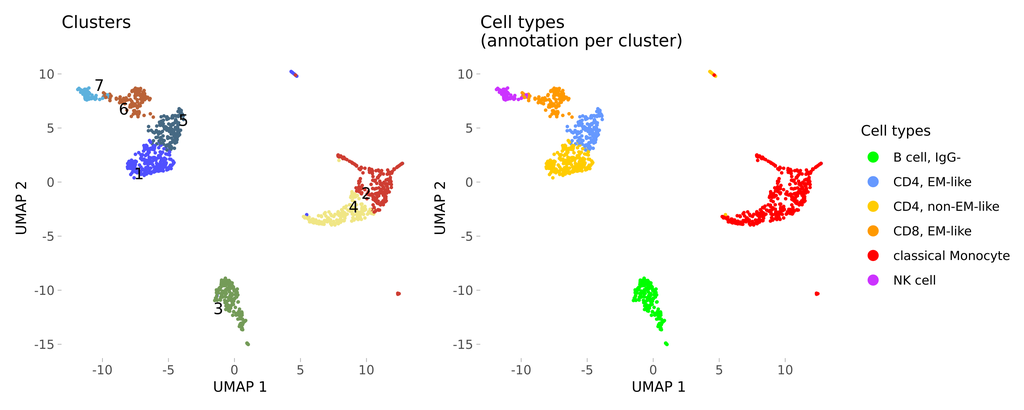

```r
# Visualization of Clustifyr annotation of clusters
cluster_cells = table(sc@active.ident)
cluster_labels = paste0(levels(sc@active.ident)," (", cluster_cells[levels(sc@active.ident)],")")
p1 = Seurat::DimPlot(sc_v3, reduction="umap", group.by="seurat_clusters", pt.size=param$pt_size) +
  scale_color_manual(values=param$col_clusters, labels=cluster_labels) +
  AddStyle(title="Clusters", xlab = "UMAP 1", ylab = "UMAP 2") +
  theme(title = element_text(size = 10)) +
  NoGrid() +
  NoLegend()
p1 = LabelClusters(p1, id="seurat_clusters")

p2 = Seurat::DimPlot(sc_v3, reduction="umap", group.by="annotation", pt.size=param$pt_size) +
  scale_color_manual(values=param$col_annotation) +
  AddStyle(title="Cell types \n(annotation per cluster)", xlab = "UMAP 1", ylab = "UMAP 2", legend_position="right", legend_title="Cell types") +
  theme(title = element_text(size = 10)) +
  NoGrid()
p = p1 + p2
p
```

## Coloured by cell type (per sample)

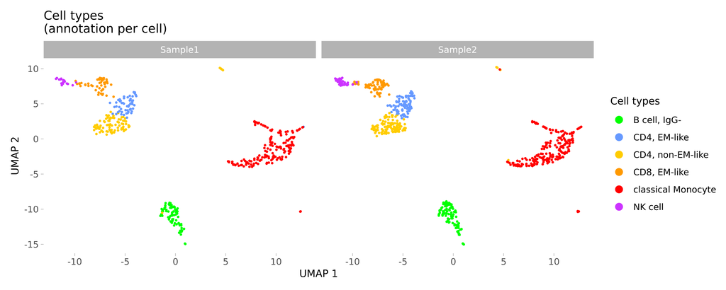

```r
# Visualization of Clustifyr annotation of cells separately per sample
p = Seurat::DimPlot(sc_v3, reduction="umap", group.by="annotation", split.by = "orig.ident", pt.size=param$pt_size, ncol = 3) +
  scale_color_manual(values=param$col_annotation) +
  AddStyle(title="Cell types \n(annotation per cell)", xlab = "UMAP 1", ylab = "UMAP 2", legend_position="right", legend_title="Cell types") +
  theme(title = element_text(size = 10)) +
  NoGrid()
p
```

## Fraction of sample per cell type

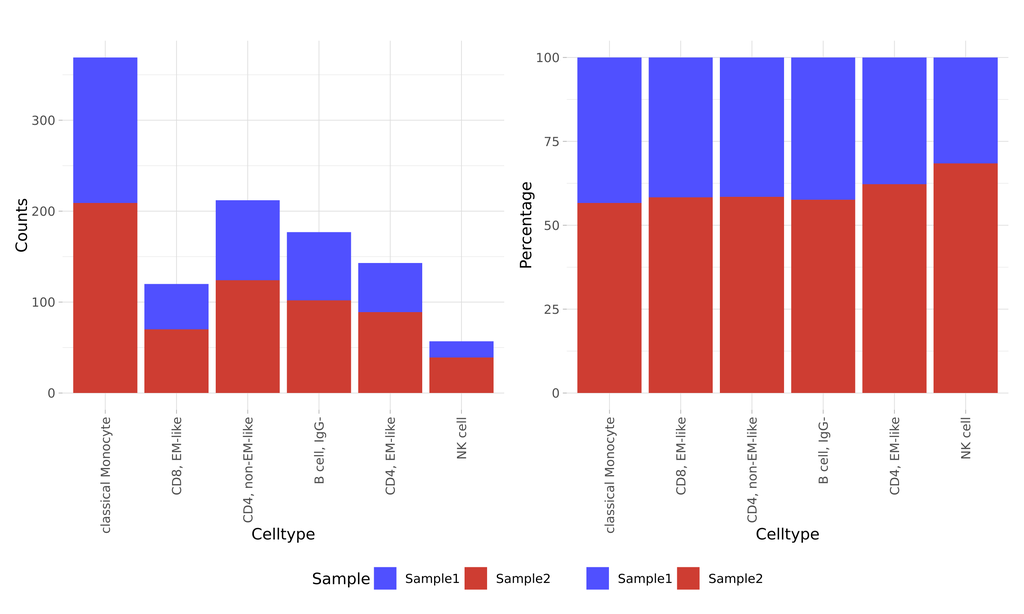

```r
# Set
cell_samples = levels(sc_v3$orig.ident)
cell_celltype = unique(sc_v3$annotation)

# Make count table
tbl = dplyr::count(sc_v3[[c("orig.ident", "annotation")]], orig.ident, annotation) %>% tidyr::pivot_wider(names_from="annotation", values_from=n, values_fill=0) %>% as.data.frame()
rownames(tbl) = paste0(tbl[,"orig.ident"])
tbl[,"orig.ident"] = NULL

tbl_bar = tbl[cell_samples, , drop=FALSE] %>%
  tibble::rownames_to_column(var="Sample") %>%
  tidyr::pivot_longer(cols = tidyselect::all_of(cell_celltype), names_to="Celltype", values_to="Counts")
tbl_bar$Counts = as.numeric(tbl_bar$Counts)
tbl_bar$Celltype <- factor(tbl_bar$Celltype,levels = cell_celltype)
tbl_bar$Sample <- factor(tbl_bar$Sample, levels = cell_samples)

# Plot counts
p1 = ggplot(tbl_bar, aes(x=Celltype, y=Counts, fill=Sample)) +
  geom_bar(stat="identity" ) +
  AddStyle(title="",
           fill=param$col_samples,
           legend_title="Sample",
           legend_position="bottom") +
  theme(axis.text.x = element_text(angle = 90, vjust = 0.5, hjust=1))

# Make table with percentages
tbl_perc = round(t(tbl) / colSums(tbl) * 100, 2) %>% t() %>% as.data.frame()

tbl_bar_perc = tbl_perc[cell_samples, , drop=FALSE] %>%
  tibble::rownames_to_column(var="Sample") %>%
  tidyr::pivot_longer(cols = tidyselect::all_of(cell_celltype), names_to="Celltype", values_to="Percentage")
tbl_bar_perc$Percentage = as.numeric(tbl_bar_perc$Percentage)
tbl_bar_perc$Celltype <- factor(tbl_bar_perc$Celltype,levels = cell_celltype)
tbl_bar_perc$Sample <- factor(tbl_bar_perc$Sample, levels = cell_samples)

# Plot percentages
p2 = ggplot(tbl_bar_perc, aes(x=Celltype, y=Percentage, fill=Sample)) +
  geom_bar(stat="identity" ) +
  AddStyle(title="",
           fill=param$col_samples,
           legend_title="",
           legend_position="") +
  theme(axis.text.x = element_text(angle = 90, vjust = 0.5, hjust=1))

p = p1 + p2 + patchwork::plot_layout(guides = "collect") & theme(legend.position = 'bottom')
p
```

## Fraction of cell types per sample

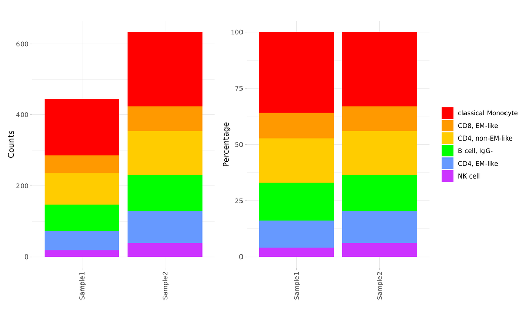

```r
# Plot counts
p1 = ggplot(tbl_bar, aes(x=Sample, y=Counts, fill=Celltype)) +
  geom_bar(stat="identity" ) +
  AddStyle(title="", xlab = "",
           fill=param$col_annotation,
           legend_title="",
           legend_position="") +
  theme(axis.text.x = element_text(angle = 90, vjust = 0.5, hjust=1))

# Calculate percentages
tbl_perc = round(t(tbl) / colSums(t(tbl)) * 100, 2) %>% t() %>% as.data.frame()
tbl_perc = round(tbl / rowSums(tbl) * 100, 2) %>% as.data.frame()

# Plot percentages
tbl_bar_perc = tbl_perc[cell_samples, , drop=FALSE] %>%
  tibble::rownames_to_column(var="Sample") %>%
  tidyr::pivot_longer(cols = tidyselect::all_of(cell_celltype), names_to="Cell_type", values_to="Percentage")
tbl_bar_perc$Percentage = as.numeric(tbl_bar_perc$Percentage)
tbl_bar_perc$Cell_type <- factor(tbl_bar_perc$Cell_type,levels = cell_celltype)
tbl_bar_perc$Sample <- factor(tbl_bar_perc$Sample, levels = cell_samples)

p2 = ggplot(tbl_bar_perc, aes(x=Sample, y=Percentage, fill=Cell_type)) +
  geom_bar(stat="identity" ) +
  AddStyle(title="", xlab = "",
           legend_position="right",
           fill=param$col_annotation) +
  theme(axis.text.x = element_text(angle = 90, vjust = 0.5, hjust=1))

p = p1 + p2 + patchwork::plot_layout(guides = "collect")
p
```

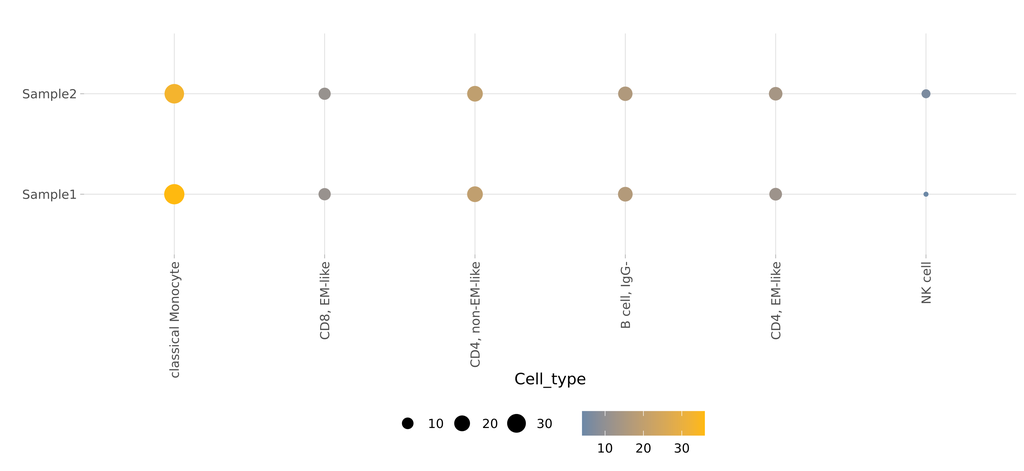

```r
p = ggplot(data = tbl_bar_perc, aes(x = Cell_type, y = Sample)) +
  geom_point(aes(color = Percentage, size = ifelse(Percentage==0, NA, Percentage))) +
  labs(col="Percentage", size="") +
  scale_colour_gradient2(low="navy", mid="steelblue", high="darkgoldenrod1") +
  #viridis::scale_color_viridis(option = "D") +
  AddStyle(title="", ylab="", legend_position="bottom") +
  theme(axis.text.x = element_text(angle=90, hjust=1, vjust=.5)) +
  guides(size=guide_legend(order=1))

p
```

```r
 sc = scCustomize::Convert_Assay(seurat_object = sc_v3, convert_to = "V5", assay = "RNA")
```

× **(Message)**  
Converting assay “RNA” from Assay to Assay5.

# Data export

```r
# Add experiment details
Seurat::Misc(sc, "experiment") = list(project_id=param$project_id, date=Sys.Date(), species=gsub("_gene_ensembl", "", param$mart_dataset))

# Add parameter
Seurat::Misc(sc, "parameters") = param

# Add technical output (note: cannot use Misc function here)
sc@misc$technical = data.frame(ScrnaseqSessionInfo(param$path_to_git))
```

```r
### Export seurat object
saveRDS(sc, file=file.path(param$path_out, "data", "sc.rds"))
```

```r
### Convert data
################################################################################

### Export to Loupe Cell Browser
if (all(param$path_data$type == "10x")) {

  # Export reductions (umap, pca, others)
  for(r in Seurat::Reductions(sc)) {
    write.table(Seurat::Embeddings(sc, reduction=r)[,1:2] %>% as.data.frame() %>% tibble::rownames_to_column(var="Barcode"),
                file=file.path(param$path_out, "data", paste0("Loupe_projection_", r, ".csv")), col.names=TRUE, row.names=FALSE, quote=FALSE, sep=",")
  }

  # Export categorical metadata
  loupe_meta = sc@meta.data
  idx_keep = sapply(1:ncol(loupe_meta), function(x) !is.numeric(loupe_meta[,x]))
  write.table(x=loupe_meta[, idx_keep] %>% tibble::rownames_to_column(var="barcode"),
              file=file.path(param$path_out, "data", "Loupe_metadata.csv"), col.names=TRUE, row.names=FALSE, quote=FALSE, sep=",")
}



### Export as andata object (h5ad file)
# Convert Seurat v5 single cell object to anndata object
# Does not work for SCT at the moment
# However, it would contain counts and data layer
#scCustomize::as.anndata(x = sc, file_path = file.path(param$path_out, "data"), file_name = "sc_anndata.h5ad", assay="RNA",
#                        main_layer = "data", other_layers = "counts", transer_dimreduc = TRUE, verbose = FALSE)

# scesy only worked for v3 and v4 objects
# Convert to V3/4/Assay structure
sc_v3 = scCustomize::Convert_Assay(seurat_object = sc, convert_to = "V3", assay = "RNA")

# Convert Seurat v3 single cell object to anndata object
adata = sceasy::convertFormat(sc_v3, from="seurat", to="anndata", outFile=NULL, assay=Seurat::DefaultAssay(sc_v3))
# Write to h5ad file
adata$write(file.path(param$path_out, "data", "sc_anndata.h5ad"), compression="gzip")



### Export count matrix
invisible(ExportSeuratAssayData(sc,
                                dir=file.path(param$path_out, "data", "counts"),
                                assays=param$assay_raw,
                                slot="counts",
                                include_cell_metadata_cols=colnames(sc[[]]),
                                metadata_prefix=paste0(param$project_id, ".")))


### Export metadata
openxlsx::write.xlsx(x=sc[[]] %>% tibble::rownames_to_column(var="Barcode"), file=file.path(param$path_out, "data", "cell_metadata.xlsx"), rowNames=FALSE, colNames=TRUE)
```

**Export seurat object**

We export the assay data, cell metadata, clustering and visualization.

Result files:  
* sc.rds: Seurat object for import into R  
* cell_metadata.xlsx: Cell metadata in excel format  
* counts folder: Contains raw count matrix of the entire dataset (sparse matrix)

**Export as andata object**

We export the assay data, cell metadata, clustering and visualization in andata format.

**Export to Loupe Cell Browser**

Result files are:  
* Loupe_projection_(umap|pca|…).csv: Seurat UMAP/PCA/… projections for visualization  
* Loupe_metadata.csv: Seurat cell meta data including clusters and cell cycle phases

Projections can be imported in Loupe via “Import Projection”, cell meta data via “Import Categories” and gene sets via “Import Lists”.

# Parameters and software versions

The following parameters were used to run the workflow.

**Parameters**

```r
out = ScrnaseqParamsInfo(params=param)

knitr::kable(out, align="l") %>%
  kableExtra::kable_styling(bootstrap_options=c("striped", "hover"), full_width=FALSE, position="left")
```

| Name | Value |
| --- | --- |
| path_to_git | /mnt/ngsnfs/single_cell_dev/scRNAseq_processing/sc_analysis |
| path_to_basic_settings | /mnt/ngsnfs/single_cell_dev/scRNAseq_processing/sc_analysis/basic_settings.R |
| path_to_advanced_settings | /mnt/ngsnfs/single_cell_dev/scRNAseq_processing/sc_analysis/advanced_settings.R |
| scriptname | scripts/dataset_mapping/cell_annotation_clustifyr.Rmd |
| author | kosankem |
| assay_raw | RNA |
| downsample_cells_equally | FALSE |
| cell_filter | nFeature_RNA:20, NA; nCount_RNA:200, 20000; percent_mt:0, 18; Sample1:nFeature_RNA=c(20, NA), nCount_RNA=c(200, 20000), percent_mt=c(0, 18); Sample2:nFeature_RNA=c(20, NA), nCount_RNA=c(200, 20000), p… |
| feature_filter | min_counts:1; min_cells:5; Sample1:min_counts=1, min_cells=5; Sample2:min_counts=1, min_cells=5 |
| samples_min_cells | 10 |
| norm | RNA |
| cc_remove | FALSE |
| cc_remove_all | FALSE |
| cc_rescore_after_merge | TRUE |
| integrate_samples | method:merge; dimensions:30; k_anchor:10; k_weight:100; reference:; integration_function:CCAIntegration |
| experimental_groups | homogene |
| pc_n | 8 |
| cluster_k | 20 |
| umap_k | 30 |
| cluster_resolution_test | 0.5, 0.7, 0.8 |
| cluster_resolution | 0.6 |
| marker_padj | 0.05 |
| marker_log2FC | 1 |
| marker_pct | 0.25 |
| enrichr_site | Enrichr |
| enrichr_padj | 0.05 |
| col_palette_samples | ggsci::pal_igv |
| col_palette_clusters | ggsci::pal_igv |
| col_palette_annotation | ggsci::pal_ucscgb |
| col | #0086b3 |
| col_bg | #D3D3D3 |
| pt_size | 0.5 |
| liana_methods | logfc, natmi, cellphonedb |
| liana_agg_rank_threshold | 0.01 |
| celltype | annotation |
| reduction | umap |
| predicted_score_threshold | 0.9 |
| percent_predicted_cells_threshold | 0.1 |
| project_id | Testdata |
| data | /mnt/ngsnfs/single_cell_dev/scRNAseq_processing/sc_analysis/output/Testdata/cluster_analysis/data/sc.rds |
| download_test_datasets | download_10x_pbmc_1k_healthyDonor_v3Chemistry |
| species | human |
| url_clustifyr | http://cells.ucsc.edu/?ds=covid19-influenza-response |
| cluster_col_clustifyr | Celltype |
| path_out | /mnt/ngsnfs/single_cell_dev/scRNAseq_processing/sc_analysis/output/Testdata/cell_annotation_clustifyr |
| debugging_mode | default_debugging |
| mart_dataset | hsapiens_gene_ensembl |
| mt | ^MT- |
| enrichr_dbs | GO_Biological_Process_2023, WikiPathway_2023_Human, Azimuth_2023, CellMarker_2024 |
| annotation_dbs | BlueprintEncodeData() |
| annot_version | 98 |
| annot_main | ensembl=ensembl_gene_id, symbol=external_gene_name, entrez=entrezgene_accession |
| mart_attributes | ensembl_gene_id, external_gene_name, entrezgene_accession, chromosome_name, start_position, end_position, percentage_gene_gc_content, gene_biotype, strand, description |
| path_reference | /mnt/ngsnfs/single_cell_dev/scRNAseq_processing/sc_analysis/references/hsapiens_gene_ensembl/98 |
| reference | hsapiens_gene_ensembl.v98.annot.txt |
| path_data | name:Sample1, Sample2; type:10x, 10x; path:/mnt/ngsnfs/single_cell_dev/scRNAseq_processing/sc_analysis/data/counts/sample1/, /mnt/ngsnfs/single_cell_dev/scRNAseq_processing/sc_analysis/data/counts/sam… |
| col_samples | Sample1=#5050FFFF, Sample2=#CE3D32FF |
| col_clusters | 1=#5050FFFF, 2=#CE3D32FF, 3=#749B58FF, 4=#F0E685FF, 5=#466983FF, 6=#BA6338FF, 7=#5DB1DDFF |
| col_samples_ref | sample1=#5050FFFF |
| col_clusters_ref | 1=#5050FFFF, 2=#CE3D32FF, 3=#749B58FF, 4=#F0E685FF, 5=#466983FF, 6=#BA6338FF, 7=#5DB1DDFF, 8=#802268FF |
| col_annotation_ref | Monocytes=#FF0000FF, B-cells=#FF9900FF, CD8+ T-cells=#FFCC00FF, CD4+ T-cells=#00FF00FF, NK cells=#6699FFFF |
| col_annotation | classical Monocyte=#FF0000FF, CD8, EM-like=#FF9900FF, CD4, non-EM-like=#FFCC00FF, B cell, IgG-=#00FF00FF, CD4, EM-like=#6699FFFF, NK cell=#CC33FFFF |

This report was generated using the scripts/dataset_mapping/cell_annotation_clustifyr.Rmd script. Software versions were collected at run time.

**Software versions**

```r
out = ScrnaseqSessionInfo(param$path_to_git)

knitr::kable(out, align="l") %>%
  kableExtra::kable_styling(bootstrap_options=c("striped", "hover"))
```

| Name | Value |
| --- | --- |
| Run on: | Thu Sep 05 05:28:26 PM 2024 |
| ktrns/scrnaseq | 1cdbcd62e50fabdea0664325de2bb1c2c2a054f1 |
| Container | NA |
| R | R version 4.2.1 (2022-06-23) |
| Platform | x86_64-pc-linux-gnu (64-bit) |
| Operating system | Ubuntu 20.04.6 LTS |
| Host name | hpc-rc11 |
| Host OS | #138-Ubuntu SMP Wed Jun 22 15:00:31 UTC 2022 (5.4.0-122-generic) |
| Packages | abind1.4-5, AnnotationDbi1.60.2, AnnotationHub3.6.0, assertthat0.2.1, backports1.4.1, beachmat2.14.2, beeswarm0.4.0, bibtex0.5.1, Biobase2.58.0, BiocFileCache2.6.1, BiocGenerics0.44.0, BiocManager1.30… |

# Credits and References

This Workflow was developed as module of the sc_analysis workflow at the [Research Core Unit Genomics, Hannover Medical School](https://www.mhh.de/en/genomics) (Hannover, Germany). Seurat Vignettes were initially used as templates (Hao et al. (2023), Hao et al. (2021)).

```r
# Writes knitcitations references to references.bib file.
knitcitations::write.bibtex(file=file.path(param$path_out, "references.bib"))
```

Hao, Y., Hao, S., Andersen-Nissen, E., III, W.M.M., Zheng, S., Butler, A., Lee, M.J., Wilk, A.J., Darby, C., Zagar, M., Hoffman, P., Stoeckius, M., Papalexi, E., Mimitou, E.P., Jain, J., Srivastava, A., Stuart, T., Fleming, L.B., Yeung, B., Rogers, A.J., McElrath, J.M., Blish, C.A., Gottardo, R., Smibert, P., Satija, R., 2021. Integrated analysis of multimodal single-cell data. Cell. https://doi.org/10.1016/j.cell.2021.04.048

Hao, Y., Stuart, T., Kowalski, M.H., Choudhary, S., Hoffman, P., Hartman, A., Srivastava, A., Molla, G., Madad, S., Fernandez-Granda, C., Satija, R., 2023. Dictionary learning for integrative, multimodal and scalable single-cell analysis. Nature Biotechnology. https://doi.org/10.1038/s41587-023-01767-y